# dataset_exploration

## LibriSpeech Structure

- `dev-clean`
- `dev-other`
- `test-clean`
- `test-other`
- `train-clean-100` (100 hours)
- `train-clean-360` (360 hours)
- `train-other-500` (500 hours)

All of the audio has a sampling rate of 16kHz.

```python
import os
```

```python
# change this to wherever it lives on your machine
DATA_DIR = '/home/thomas/Dir/ccny/ccny-masters-thesis/raw-data/LibriSpeech'
```

The LibriSpeech dataset (thankfully) has a standardized structure of its directories:

```
|- <url>
   |-- <speaker_id>
       |-- <chapter_id>
           |-- <speaker_id>-<chapter_id>-<snippet_id>.flac
           .
           .
           .
           |-- <speaker_id>-<chapter_id>.trans.txt
```

This makes it useful for most speech-related tasks, be it speech recognition or speaker recognition / verfication.

```python
os.listdir(DATA_DIR)
```

```
['CHAPTERS.TXT',
 'dev-clean',
 'BOOKS.TXT',
 'README.TXT',
 'LICENSE.TXT',
 'test-clean',
 'SPEAKERS.TXT']
```

Let's investigate on sample file in particular to just to get a sense of how we would interact with it.

```python
url = 'dev-clean'
```

```python
speakers = os.listdir(os.path.join(DATA_DIR, url))
speakers[0]
```

```
'6345'
```

```python
chapters = os.listdir(os.path.join(DATA_DIR, url, speakers[0]))
chapters
```

```
['93302', '64257', '93306']
```

```python
files = os.listdir(os.path.join(DATA_DIR, url, speakers[0], chapters[0]))
files[0]
```

```
'6345-93302-0013.flac'
```

## Audio Sample

Here we'll load and display the audio file using the `librosa` [library](https://librosa.org/librosa/index.html) which provides many helpful utilities for dealing with audio files. Something worth noting here is that the default sample rate for `librosa` is typically 22050Hz.

```python
import librosa
import librosa.display
import matplotlib.pyplot as plt
import IPython
```

```python
# pick an example file
sample_file_path = os.path.join(DATA_DIR, url, speakers[0], chapters[0], files[0])
sample_file_path
```

```
'/home/thomas/Dir/ccny/ccny-masters-thesis/raw-data/LibriSpeech/dev-clean/6345/93302/6345-93302-0013.flac'
```

```python
sample = os.path.basename(sample_file_path).strip('.flac')
sample
```

```
'6345-93302-0013'
```

```python
librispeech_sr = 16000
y, _ = librosa.core.load(sample_file_path, sr=librispeech_sr)
```

Now given that raw audio in waveform, we can visualize the amplitude (?) of the wave over the time of the sample.

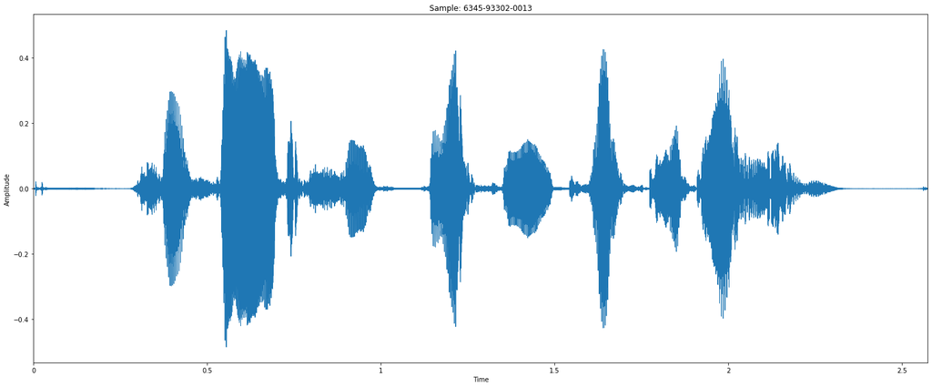

```python
# TODO: add axis label
plt.figure(figsize=(25,10))
plt.title(f'Sample: {sample}')
plt.ylabel('Amplitude')
_ = librosa.display.waveplot(y, sr=librispeech_sr)
```

What does the sample actually sound like?

```python
IPython.display.Audio(y, rate=librispeech_sr)
```

[interactive chart not shown]

And, as mentioned, LibriSpeech also provides the transcript of the audio file, which will come in handy for performing speech recognition.

```python
transcript = [
    f for f in os.listdir(os.path.join(DATA_DIR, url, speakers[0], chapters[0])) if f.endswith('.txt')
][0]
transcript
```

```
'6345-93302.trans.txt'
```

```python
# all the snippet transcripts are in the same file with their labels at the beginning
# of each line
with open(os.path.join(DATA_DIR, url, speakers[0], chapters[0], transcript), 'r') as f:
    for line in f:
        if sample in line:
            print(line)
```

```
6345-93302-0013 SHE SAID HOW FRIGHTFULLY COLD IT IS
```